# Steps and Tasks

## 1. Import the necessary libraries

```python
import numpy as np
import pandas as pd
import matplotlib.pyplot as plt
import scipy.stats as stats
import seaborn as sns     # library for advance visualization
```

## 2. Read the data as a data frame

```python
insur_data = pd.read_csv('insurance.csv')
insur_data.head()
```

|  | age | sex | bmi | children | smoker | region | charges |
| --- | --- | --- | --- | --- | --- | --- | --- |
| 0 | 19 | female | 27.900 | 0 | yes | southwest | 16884.92400 |
| 1 | 18 | male | 33.770 | 1 | no | southeast | 1725.55230 |
| 2 | 28 | male | 33.000 | 3 | no | southeast | 4449.46200 |
| 3 | 33 | male | 22.705 | 0 | no | northwest | 21984.47061 |
| 4 | 32 | male | 28.880 | 0 | no | northwest | 3866.85520 |

## 3.Perform basic EDA which should include the following and print out your insights

## at every step.

### a. Shape of the data

```python
insur_data.shape
```

```
(1338, 7)
```

**There are 1338 Observations / Rows and 7 Attributes / Columns.**

### b. Data type of each attribute

```python
insur_data.info()
```

```
<class 'pandas.core.frame.DataFrame'>
RangeIndex: 1338 entries, 0 to 1337
Data columns (total 7 columns):
age         1338 non-null int64
sex         1338 non-null object
bmi         1338 non-null float64
children    1338 non-null int64
smoker      1338 non-null object
region      1338 non-null object
charges     1338 non-null float64
dtypes: float64(2), int64(2), object(3)
memory usage: 73.3+ KB
```

### c. Checking the presence of missing values

```python
# number of missing values (only the ones recognised as missing values) in each of the attributes
pd.DataFrame( insur_data.isnull().sum(), columns= ['Number of missing values'])
```

|  | Number of missing values |
| --- | --- |
| age | 0 |
| sex | 0 |
| bmi | 0 |
| children | 0 |
| smoker | 0 |
| region | 0 |
| charges | 0 |

- There are no missing values in any of the fields for insur_data dataframe

### d. 5 point summary of numerical attributes

```python
insur_data.describe() # the output results provide the five number summary of the data.
```

|  | age | bmi | children | charges |
| --- | --- | --- | --- | --- |
| count | 1338.000000 | 1338.000000 | 1338.000000 | 1338.000000 |
| mean | 39.207025 | 30.663397 | 1.094918 | 13270.422265 |
| std | 14.049960 | 6.098187 | 1.205493 | 12110.011237 |
| min | 18.000000 | 15.960000 | 0.000000 | 1121.873900 |
| 25% | 27.000000 | 26.296250 | 0.000000 | 4740.287150 |
| 50% | 39.000000 | 30.400000 | 1.000000 | 9382.033000 |
| 75% | 51.000000 | 34.693750 | 2.000000 | 16639.912515 |
| max | 64.000000 | 53.130000 | 5.000000 | 63770.428010 |

```python
# Additionally we can see the 5 point summary individually
# Print the mean of each attribute.
print("Insurance Data:",insur_data.mean())
```

```
Insurance Data: age            39.207025
bmi            30.663397
children        1.094918
charges     13270.422265
dtype: float64
```

```python
# Print the mode of the attribute.
print(insur_data.mode())
```

```
   age   sex   bmi  children smoker     region    charges
0   18  male  32.3         0     no  southeast  1639.5631
```

```python
# Print the median values of the data.
print("Insurance Data:",insur_data.median())
# Observe that the values of mean and median are almost the same for bmi
```

```
Insurance Data: age           39.000
bmi           30.400
children       1.000
charges     9382.033
dtype: float64
```

```python
# Prints the value below which 25% of the data lies
print("Insur_data_quantile(25%):",insur_data.quantile(q=0.25))
```

```
Insur_data_quantile(25%): age           27.00000
bmi           26.29625
children       0.00000
charges     4740.28715
Name: 0.25, dtype: float64
```

```python
# Prints the value below which 50% of the data lies
print("Insur_data_quantile(50%):",insur_data.quantile(q=0.50))
```

```
Insur_data_quantile(50%): age           39.000
bmi           30.400
children       1.000
charges     9382.033
Name: 0.5, dtype: float64
```

```python
# Prints the value below which 75% of the data lies
print("Insur_data_quantile(75%):",insur_data.quantile(q=0.75))
```

```
Insur_data_quantile(75%): age            51.000000
bmi            34.693750
children        2.000000
charges     16639.912515
Name: 0.75, dtype: float64
```

### e. Distribution of ‘bmi’, ‘age’ and ‘charges’ columns

#### Histogram of bmi

```
Mean:  30.663396860986538
Median:  30.4
Mode:  32.3
```

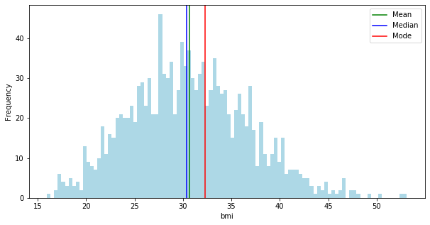

```python
mean=insur_data['bmi'].mean()
median=insur_data['bmi'].median()
mode=insur_data['bmi'].mode()

print('Mean: ',mean,'\nMedian: ',median,'\nMode: ',mode[0])

plt.figure(figsize=(10,5)) # set the figure size
plt.hist(insur_data['bmi'],bins=100,color='lightblue') #Plot the histogram

plt.axvline(mean,color='green',label='Mean')
plt.axvline(median,color='blue',label='Median')
plt.axvline(mode[0],color='red',label='Mode')

plt.xlabel('bmi')         # label the x-axis
plt.ylabel('Frequency')   # label the y-axis
plt.legend()              # Plot the legend
plt.show()
```

- the distribution for bmi is right skewed.

#### Histogram for age

```
Mean:  39.20702541106129
Median:  39.0
Mode:  18
```

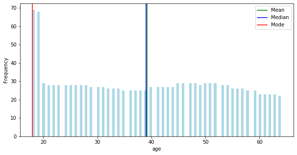

```python
mean=insur_data['age'].mean()
median=insur_data['age'].median()
mode=insur_data['age'].mode()

print('Mean: ',mean,'\nMedian: ',median,'\nMode: ',mode[0])

plt.figure(figsize=(10,5)) # set the figure size
plt.hist(insur_data['age'],bins=100,color='lightblue') #Plot the histogram

plt.axvline(mean,color='green',label='Mean')
plt.axvline(median,color='blue',label='Median')
plt.axvline(mode[0],color='red',label='Mode')

plt.xlabel('age')         # label the x-axis
plt.ylabel('Frequency')   # label the y-axis
plt.legend()              # Plot the legend
plt.show()
```

#### Histogram for 'charges'

```
Mean:  13270.422265141257
Median:  9382.033
Mode:  1639.5631
```

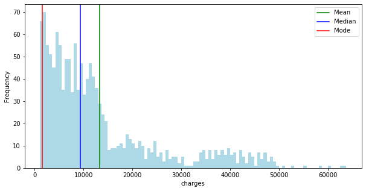

```python
mean=insur_data['charges'].mean()
median=insur_data['charges'].median()
mode=insur_data['charges'].mode()

print('Mean: ',mean,'\nMedian: ',median,'\nMode: ',mode[0])

plt.figure(figsize=(10,5)) # set the figure size
plt.hist(insur_data['charges'],bins=100,color='lightblue') #Plot the histogram

plt.axvline(mean,color='green',label='Mean')
plt.axvline(median,color='blue',label='Median')
plt.axvline(mode[0],color='red',label='Mode')

plt.xlabel('charges')     # label the x-axis
plt.ylabel('Frequency')   # label the y-axis
plt.legend()              # Plot the legend
plt.show()
```

- the distribution for charges is right skewed.

### f. Measure of skewness of ‘bmi’, ‘age’ and ‘charges’ columns

```python
insur_data.skew()
```

```
age         0.055673
bmi         0.284047
children    0.938380
charges     1.515880
dtype: float64
```

- Measure of skweness for 'bmi' is 0.284047, 'age' is 0.055673, 'charges' is 1.515880

#### Distribution to check measure of skewness for 'bmi'

```
C:\Users\Neema MV\Anaconda3\lib\site-packages\ipykernel_launcher.py:12: MatplotlibDeprecationWarning:
The 'normed' kwarg was deprecated in Matplotlib 2.1 and will be removed in 3.1. Use 'density' instead.
  if sys.path[0] == '':
```

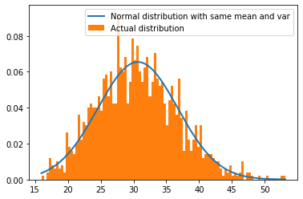

```python
#convert pandas DataFrame object to numpy array and sort
h = np.asarray(insur_data['bmi'])
h = sorted(h)

#use the scipy stats module to fit a normal distirbution with same mean and standard deviation
fit = stats.norm.pdf(h, np.mean(h), np.std(h))

#plot both series on the histogram
plt.plot(h,fit,'-',linewidth = 2,label="Normal distribution with same mean and var")
plt.hist(h,normed=True,bins = 100,label="Actual distribution")
plt.legend()
plt.show()
```

- We can see int the above graph that it is positive skewed with skewness score 0.284047

#### Distribution to check measure of skewness for 'age'

```
C:\Users\Neema MV\Anaconda3\lib\site-packages\ipykernel_launcher.py:9: MatplotlibDeprecationWarning:
The 'normed' kwarg was deprecated in Matplotlib 2.1 and will be removed in 3.1. Use 'density' instead.
  if __name__ == '__main__':
```

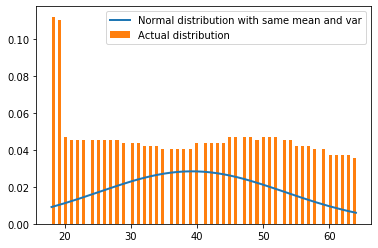

```python
i = np.asarray(insur_data['age'])
i = sorted(i)

#use the scipy stats module to fit a normal distirbution with same mean and standard deviation
fit = stats.norm.pdf(i, np.mean(i), np.std(i))

#plot both series on the histogram
plt.plot(i,fit,'-',linewidth = 2,label="Normal distribution with same mean and var")
plt.hist(i,normed=True,bins = 100,label="Actual distribution")
plt.legend()
plt.show()
```

- We can see int the above graph that it is close to zero skewness with the skewness score 0.055673

```
C:\Users\Neema MV\Anaconda3\lib\site-packages\ipykernel_launcher.py:9: MatplotlibDeprecationWarning:
The 'normed' kwarg was deprecated in Matplotlib 2.1 and will be removed in 3.1. Use 'density' instead.
  if __name__ == '__main__':
```

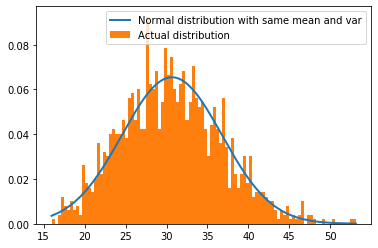

```python
j = np.asarray(insur_data['charges'])
j = sorted(h)

#use the scipy stats module to fit a normal distirbution with same mean and standard deviation
fit = stats.norm.pdf(j, np.mean(j), np.std(j))

#plot both series on the histogram
plt.plot(j,fit,'-',linewidth = 2,label="Normal distribution with same mean and var")
plt.hist(j,normed=True,bins = 100,label="Actual distribution")
plt.legend()
plt.show()
```